# Scenario 3: CCDSS

Andriy Koval

Created on 2019-06-05. Updated on 2019-06-19.

# overview

This document narrates the demonstration of the `(prep + plot + print)` technique using the data from Canadian Chronic Disease Survaillance System (CCDSS). We follow the phases of transforming a concept `ggplot2` plot into a sequence of custom functions that automate graph production. View data description on [this README.md](https://github.com/dss-ialh/graph-making-scenarios/blob/master/data-public/raw/scenario-3/README.md).

Another demonstration of this technique was created data from VADA 2019 Summer School Data Challenge. See github.com/andkov/vada-2019-summer-school repository for reproducible scripts. The data, however, is not available publically. Please contact [VADA program](http://vada.cs.umanitoba.ca/contact/) coordinator to enquire about data access.

We will proceed building a system for reproducible graphing in the following sequence of phases:

- PHASE 0 - explore the data
- PHASE 1 - build the plot
- PHASE 2 - build the `plot` function
- PHASE 3 - isolate the `prep` step
- PHASE 4 - isolate the `print` step
- PHASE 5 - serialize graph production
- PHASE 6 - `place` graphs onto the canvas

Each phase marks a milestone in the expanding complexity of the visualization system.

## disclaimer

- This essay is more about making graphs than about analyzing data
- This essay is more about demonstrating a technique than about prescribing a framework. ([*“Frameworks are like toothbrushes: everyone’s got one and no-one wants to use anyone else’s”*](https://twitter.com/trishgreenhalgh/status/891674763285942272))

## mindset

Data scientists describe the ultimate reality about data using various dialets of expression. Each translation has its benefits and disadvantages. We need them all to tell a good story.

[figure not shown]

No one language is better than the other. Each allows for different shades of distinction in model specification.

[figure not shown]

# set the scene

## load packages

```r
# Attach these packages so their functions don't need to be qualified
library(magrittr)          # enables piping : %>%
library(dplyr)             # data wrangling
library(knitr)             # tables
library(ggplot2)           # graphs
library(viridis)           # for colorblind friendly color palettes
requireNamespace("dplyr")  # data wrangling
requireNamespace("readr")  # for data input
requireNamespace("tidyr")  # for data manipulation
requireNamespace("testit") # for asserting conditions meet expected patterns
requireNamespace("car")    # for its `recode()` function
```

## load sources

```r
# Call `base::source()` on any repo file that defines external functions needed in this report.
# Ideally, no real operations are performed in these scripts.
base::source("./scripts/common-functions.R") # used in multiple reports
base::source("./scripts/graphing/graph-presets.R") # fonts, colors, themes
```

## declare globals

```r
# location of the data sources
path_input  <- "./data-public/raw/scenario-3/PHAC_Infobase_CCDSS_-8586421808967913043.csv" # mental illness
# path_input   <- "./data-public/raw/scenario-3/PHAC_Infobase_CCDSS_-8586421810172823624.csv" # anxiety & mood
output_format = "html"
```

## load data

View [`./data-unshared/contents.md`](https://github.com/dss-ialh/graph-making-scenarios/tree/master/data-public/raw/scenario-3) for data dictionary and the retrieval specifications.

```r
# see ./data-unshared/contents.md for origin of the data
ds0 <- path_input %>% readr::read_csv(skip = 3) %>% tibble::as_tibble()
ds0 %>% dplyr::glimpse(60)
```

```
Observations: 4,257
Variables: 12
$ Area                <chr> "Canada", "Canada", "Canada...
$ Condition           <chr> "Use of health services for...
$ `Age Group`         <chr> "'1+'", "'1-19'", "'20-34'"...
$ Sex                 <chr> "Both sexes", "Both sexes",...
$ Year                <dbl> 2000, 2000, 2000, 2000, 200...
$ Rate                <dbl> 10.71, 3.04, 11.11, 14.29, ...
$ `Rate CV`           <dbl> 0.05, 0.21, 0.12, 0.09, 0.1...
$ `Rate_95%_CI_Lower` <dbl> 10.70, 3.03, 11.08, 14.26, ...
$ `Rate_95%_CI_Upper` <dbl> 10.72, 3.05, 11.13, 14.31, ...
$ Number              <dbl> 3364580, 236410, 723770, 11...
$ Population          <dbl> 31412970, 7781830, 6517490,...
$ X12                 <lgl> NA, NA, NA, NA, NA, NA, NA,...
```

# PHASE 0 - explore

## tweak data

```r
# to trace the tweaks
ds1 <- ds0 # start with the identical copy
# to systematize variable name for easier remembering and typing
names(ds1) <- gsub(" ","_", names(ds1)) # to make into a single word (all word chars)
names(ds1) <- gsub("%","", names(ds1))  # to remove special characters
names(ds1) <- tolower(names(ds1))       # to standardize spellining

ds1 <- ds1 %>% dplyr::select(-x12) # to remove an empty column

ds1 <- ds1 %>%
  dplyr::mutate(
    age_group = gsub("'","",age_group) # to remove extra set of quotes
  ) %>%
  dplyr::filter(!is.na(condition)) # to remove notes at the end of the spreadsheet
ds1 %>% dplyr::glimpse(60)
```

```
Observations: 4,242
Variables: 11
$ area             <chr> "Canada", "Canada", "Canada", ...
$ condition        <chr> "Use of health services for mo...
$ age_group        <chr> "1+", "1-19", "20-34", "35-49"...
$ sex              <chr> "Both sexes", "Both sexes", "B...
$ year             <dbl> 2000, 2000, 2000, 2000, 2000, ...
$ rate             <dbl> 10.71, 3.04, 11.11, 14.29, 14....
$ rate_cv          <dbl> 0.05, 0.21, 0.12, 0.09, 0.12, ...
$ rate_95_ci_lower <dbl> 10.70, 3.03, 11.08, 14.26, 14....
$ rate_95_ci_upper <dbl> 10.72, 3.05, 11.13, 14.31, 14....
$ number           <dbl> 3364580, 236410, 723770, 11277...
$ population       <dbl> 31412970, 7781830, 6517490, 78...
```

## inspect-1 raw

```r
# to demonstrate the principle of custom functions
print_distinct <- function(
  d
  ,group_by_variables
){
  # define values needed for testing and development inside the function:
  # d <- ds0
  # group_by_variables <- "area"
  # group_by_variables <- c("area","age_group")

  d_out <- d %>%
    dplyr::group_by(.dots = c(group_by_variables) ) %>%
    dplyr::count()

  return(d_out)
}
# How to use
ds1 %>% print_distinct(group_by_variables = "area")
```

```
# A tibble: 13 x 2
# Groups:   area [13]
   area                          n
   <chr>                     <int>
 1 Alberta                     336
 2 British Columbia            336
 3 Canada                      336
 4 Manitoba                    336
 5 New Brunswick               336
 6 Newfoundland and Labrador   336
 7 Northwest Territories       336
 8 Nova Scotia                 336
 9 Nunavut                     231
10 Ontario                     336
11 Prince Edward Island        336
12 Quebec                      336
13 Saskatchewan                315
```

```r
# to demonstrate how to vary the input (values for the argument of the function)
# ds1 %>% print_distinct(group_by_variables = "condition")
# ds1 %>% print_distinct(group_by_variables = "age_group")
# ds1 %>% print_distinct(group_by_variables = c("area","age_group") )
# TODO: instead of `n` compute the average of a specific variable
```

## declare components

```r
# to help remember how each variable could be used during serial application
varnames_categorical <- c("area","condition", "age_group", "sex","year")
varnames_continuous  <- c(
  "rate", "rate_cv", "rate_95_ci_lower","rate_95_ci_upper", "number","population"
)
# to help with mapping data space into the visualization space
varnames_rate     <- c("rate", "rate_cv","rate_95_ci_lower","rate_95_ci_upper")
varnames_measure  <- c(varnames_rate,"number","population" )
varnames_time     <- c("year")
varnames_design   <- c("area","age_group","sex", "condition")
```

## inspect-2 categorical

```r
# to explore the scles of the CATEGORICAL variables
for(i in varnames_categorical){
  ds1 %>%
    print_distinct( group_by_variables = i ) %>%
    neat() %>% # to apply custom style for html canvas
    print()    # because inside the loop
}
```

| area | n |
| --- | --- |
| Alberta | 336 |
| British Columbia | 336 |
| Canada | 336 |
| Manitoba | 336 |
| New Brunswick | 336 |
| Newfoundland and Labrador | 336 |
| Northwest Territories | 336 |
| Nova Scotia | 336 |
| Nunavut | 231 |
| Ontario | 336 |
| Prince Edward Island | 336 |
| Quebec | 336 |
| Saskatchewan | 315 |

| condition | n |
| --- | --- |
| Use of health services for mood and anxiety disorders (annual) | 4242 |

| age_group | n |
| --- | --- |
| 1-19 | 606 |
| 1+ | 606 |
| 20-34 | 606 |
| 35-49 | 606 |
| 50-64 | 606 |
| 65-79 | 606 |
| 80+ | 606 |

| sex | n |
| --- | --- |
| Both sexes | 1414 |
| Females | 1414 |
| Males | 1414 |

| year | n |
| --- | --- |
| 2000 | 252 |
| 2001 | 252 |
| 2002 | 252 |
| 2003 | 252 |
| 2004 | 252 |
| 2005 | 273 |
| 2006 | 273 |
| 2007 | 273 |
| 2008 | 273 |
| 2009 | 273 |
| 2010 | 273 |
| 2011 | 273 |
| 2012 | 273 |
| 2013 | 273 |
| 2014 | 273 |
| 2015 | 252 |

## inspect-3 continuous

```r
# to explore the scales of CONTINUOUS variables
ds1 %>%
  dplyr::select_(.dots = varnames_continuous) %>%
  explore::describe() %>% neat()
```

| variable | type | na | na_pct | unique | min | mean | max |
| --- | --- | --- | --- | --- | --- | --- | --- |
| rate | dou | 31 | 0.7 | 1596 | 0.91 | 9.87 | 22.47 |
| rate_cv | dou | 31 | 0.7 | 394 | 0.05 | 1.93 | 31.62 |
| rate_95_ci_lower | dou | 31 | 0.7 | 1571 | 0.74 | 9.60 | 22.20 |
| rate_95_ci_upper | dou | 31 | 0.7 | 1576 | 0.99 | 10.17 | 22.74 |
| number | dou | 0 | 0.0 | 2902 | 0.00 | 105923.92 | 3617090.00 |
| population | dou | 0 | 0.0 | 3969 | 50.00 | 1025646.57 | 36691810.00 |

# PHASE 1 - graph

## sketch the space

```r
# now let us find ways to look at/in/with data.
# the above analysis helps us to conceptualize available variables as:

#  I - DATA space

## MEASURE - rate       # crude rate (includes cv, ci_upper, ci_lower)
## MEASURE - number     # count of cases of the condition
## MEASURE - population # total alive
## TIME    - year       # fiscal
## DESIGN  - area       ( 12 provinces + 1 total )
## DESIGN  - age_group  ( 6 gropus + 1 total )
## DESIGN  - sex        ( 2 gropus + 1 total )
## DESIGN  - condition  ( 1 )

#  II - VISUALIZATION space

## INNER - horizontal - TIME    - (year)
## INNER - vertical   - MEASURE - (rate)
## INNER - color      - DESIGN  - (sex)
## OUTER - horizontal - DESIGN  - (area)
## OUTER - vertial    - DESIGN  - (age_group)
```

## graph-1 basic

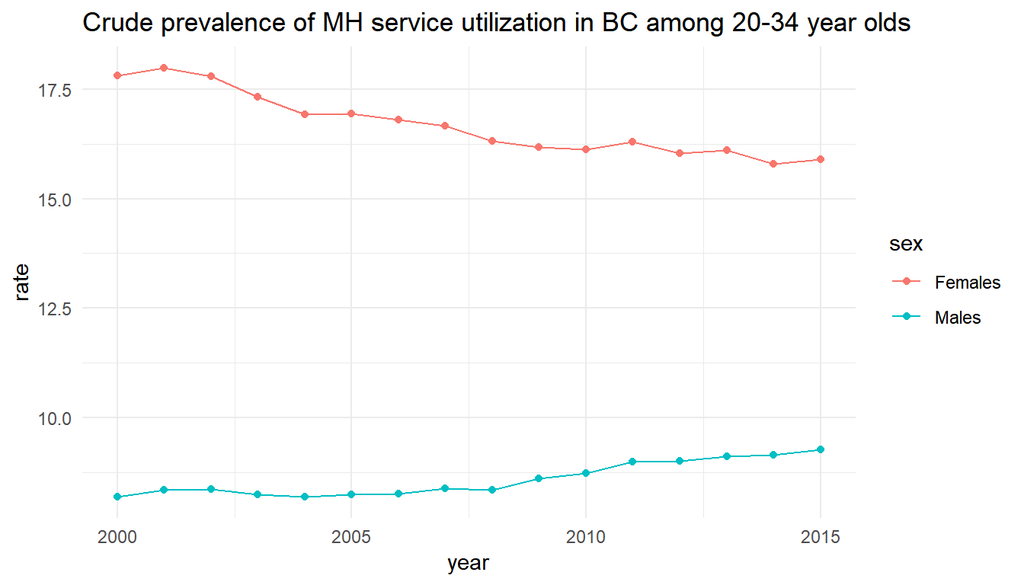

```r
# let us sketch the most basic graph in 3 internal dimensions of our blueprint
# notice that we isolate a single value on all other dimensions
g1 <- ds1 %>%
  dplyr::filter(area       ==  "British Columbia" ) %>%
  dplyr::filter(age_group  ==  "20-34" ) %>%
  dplyr::filter(sex       %in% c("Males","Females") ) %>%
  ggplot(aes(
    x      = year
    ,y     = rate
    ,color = sex
  ))+
  geom_point()+
  geom_line( aes(group = sex) )+
  theme_minimal()+
  labs( title = "Crude prevalence of MH service utilization in BC among 20-34 year olds")
g1
```

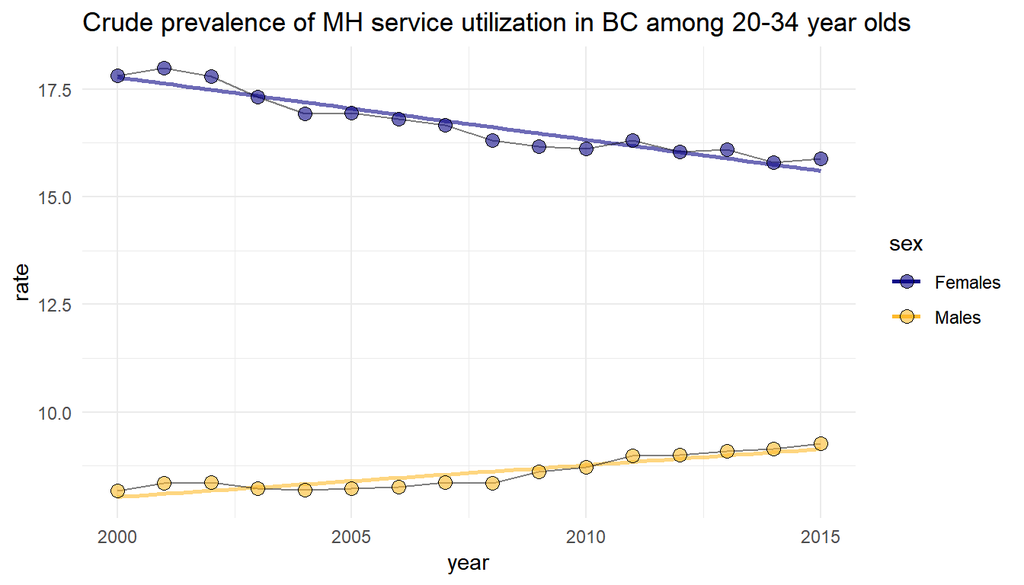

```r
# to demonstrate how we can enhance the effectiveness of information display
g1a <- ds1 %>%
  dplyr::filter(area       ==  "British Columbia" ) %>%
  dplyr::filter(age_group  ==  "20-34" ) %>%
  dplyr::filter(sex       %in% c("Males","Females") ) %>%
  ggplot(aes(
    x      = year
    ,y     = rate
    ,fill  = sex # maps onto a different aesthetic than `color = `
  ))+
  geom_smooth(method = "lm", se = F, size=1, aes(color=sex))+ # to show linear trend
  geom_line(aes(group = sex), alpha = .5 )+                   # to minimize emphasis
  geom_point(shape = 21, color="black", size = 3)+            # to minimize ink
  scale_fill_viridis_d( end=.85, option="plasma",alpha = .6)+ # colorblind-friendly
  scale_color_viridis_d(end=.85, option="plasma",alpha = .6)+ # colorblind-friendly
  theme_minimal()+
  labs( title = "Crude prevalence of MH service utilization in BC among 20-34 year olds")
g1a
```

```r
# AESTHETIC ASIDE: the following values seems to work well in this context
# scale_color_viridis_d(end=.75)+
# scale_color_viridis_d(end=.85, option="plasma")+
# scale_color_viridis_d(end=.70, option="magma")+
# scale_color_viridis_d(end=.80, option="inferno")+
```

## graph-2 wrap

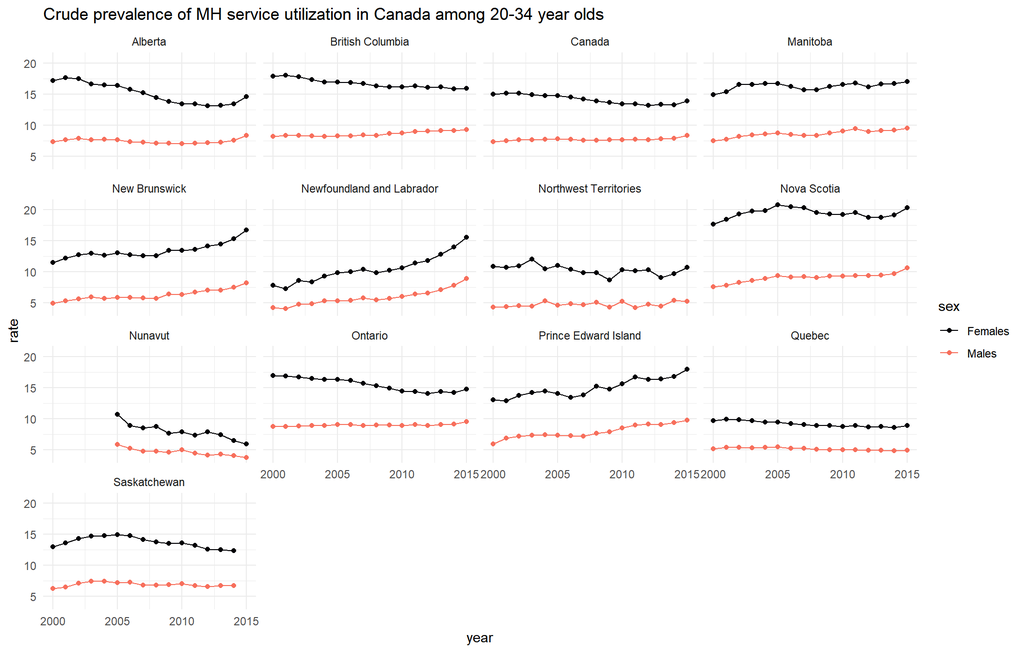

```r
# now we can introduce external dimensions
# notice we remove the filter and feed `area` to ggplot2::facet_wrap()
g2a <- ds1 %>%
  # dplyr::filter(area       ==  "British Columbia" ) %>% # to enable faceting
  dplyr::filter(age_group  ==  "20-34" ) %>%
  dplyr::filter(sex       %in% c("Males","Females") ) %>%
  ggplot(aes(
    x      = year
    ,y     = rate
    ,color = sex
  ))+
  geom_line(aes(group= sex))+
  geom_point()+
  facet_wrap("area")+ # we can becasue we removed filter
  scale_color_viridis_d(end=.70, option="magma")+
  theme_minimal()+
  labs( title = "Crude prevalence of MH service utilization in Canada among 20-34 year olds")
g2a
```

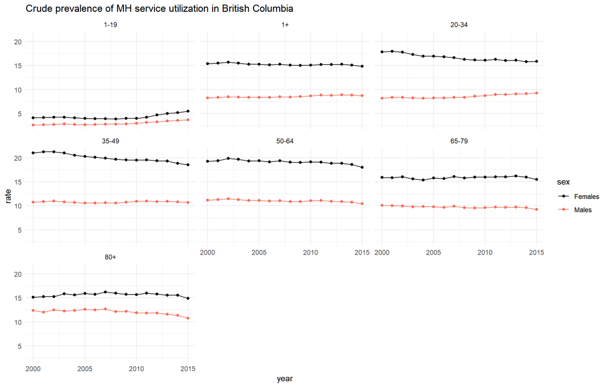

```r
# see more about the viridis package:
# https://cran.r-project.org/web/packages/viridis/vignettes/intro-to-viridis.html

# now let us feed `age_group` to ggplot2::facet_wrap()
g2b <- ds1 %>%
  dplyr::filter(area       ==  "British Columbia" ) %>%
  # dplyr::filter(age_group  ==  "20-34" ) %>%
  dplyr::filter(sex       %in% c("Males","Females") ) %>%
  ggplot(aes(
    x      = year
    ,y     = rate
    ,color = sex
  ))+
  geom_point()+
  geom_line(aes(group= sex) )+
  facet_wrap("age_group")+ # to change what we facet on
  scale_color_viridis_d(end=.70, option="magma")+
  theme_minimal()+
  labs( title = "Crude prevalence of MH service utilization in British Columbia")
g2b
```

## graph-2 grid

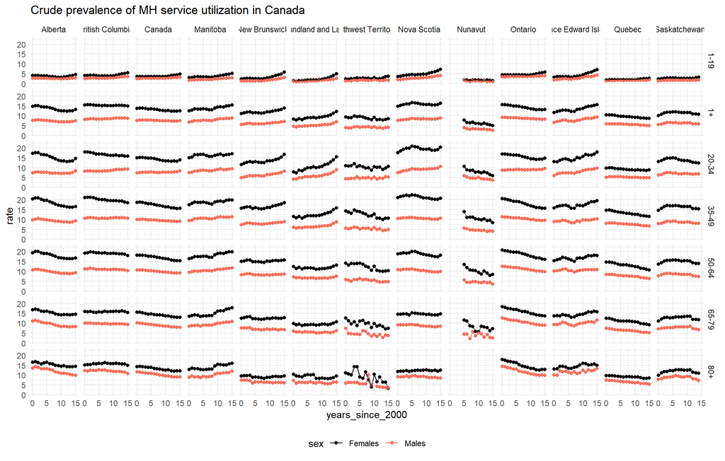

```r
# now let facet_grid on two demensions
g2c <- ds1 %>%
  dplyr::mutate(
    years_since_2000 = year - 2000 # for shorter axis labels
  ) %>%
  # dplyr::filter(area       ==  "British Columbia" ) %>%
  # dplyr::filter(age_group  ==  "20-34" ) %>%
  dplyr::filter(sex       %in% c("Males","Females") ) %>%
  ggplot(aes(
    x      = years_since_2000
    ,y     = rate
    ,color = sex
  ))+
  geom_point()+
  geom_line(aes(group=sex))+
  facet_grid(age_group ~ area)+ # new
  scale_color_viridis_d(end=.70, option="magma")+
  theme_minimal()+
  theme(legend.position = "bottom")+
  labs( title = "Crude prevalence of MH service utilization in Canada")
g2c
```

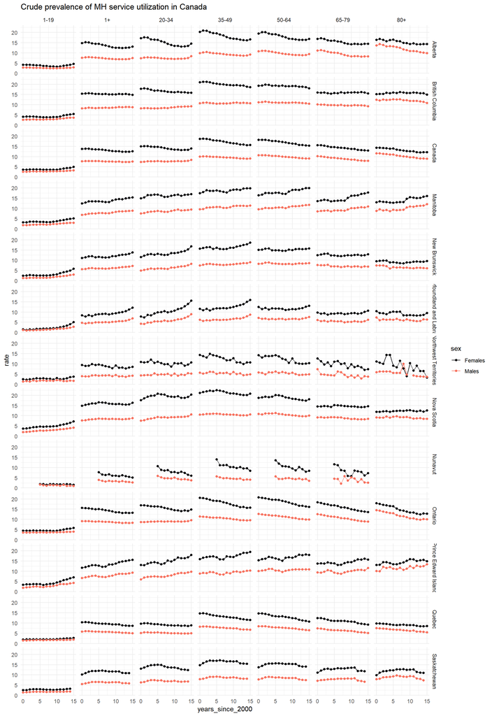

```r
g2d <- ds1 %>%
  dplyr::mutate(
    years_since_2000 = year - 2000 # for shorter axis labels
  ) %>%
  # dplyr::filter(area       ==  "British Columbia" ) %>%
  # dplyr::filter(age_group  ==  "20-34" ) %>%
  dplyr::filter(sex       %in% c("Males","Females") ) %>%
  ggplot(aes(
    x      = years_since_2000
    ,y     = rate
    ,color  = sex
  ))+
  geom_line(aes(group=sex))+
  geom_point()+
  facet_grid(area ~ age_group)+ # change faceting
  scale_color_viridis_d(end=.70, option="magma")+
  theme_minimal()+
  labs( title = "Crude prevalence of MH service utilization in Canada")
g2d
```

# PHASE 2 - make plot

```r
# suppose, we have settled on the graphical form `g2d` (immediately above)
g2d <- ds1 %>%
  dplyr::mutate(
    years_since_2000 = year - 2000
  ) %>%
  dplyr::filter(sex       %in% c("Males","Females") ) %>%
  ggplot(aes(
    x      = years_since_2000 # new
    ,y     = rate
    ,color  = sex
  ))+
  geom_point()+
  geom_line(aes(group=sex))+
  facet_grid(area ~ age_group)+
  scale_color_viridis_d(end=.70, option="magma")+
  theme_minimal()+
  labs( title = "Crude prevalence of MH service utilization in Canada")
```

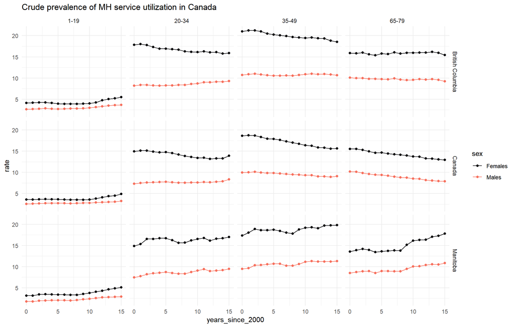

```r
# now let us re-express this plot as a custom function
make_plot_1_basic <- function(
  d
  ,measure = "rate"
){
  d1 <- d %>%
    dplyr::mutate(
      years_since_2000 = year - 2000 # to create a shorter axis label
    )

  g_out <- d1 %>%
    ggplot(aes_string(
       x      = "years_since_2000"
       ,y     = measure
       ,color  = "sex"
    ))+
    geom_point()+
    geom_line(aes(group=sex))+
    facet_grid(area ~ age_group)+
    scale_color_viridis_d(end=.70, option="magma")+
    theme_minimal()+
    labs( title = "Crude prevalence of MH service utilization in Canada")
  return(g_out)
}
# how to use:
ds1 %>%
  dplyr::filter(sex       %in% c("Males","Females") ) %>%
  dplyr::filter(age_group %in% c("1-19", "20-34", "35-49", "65-79")) %>%
  dplyr::filter(area %in% c("Canada", "Manitoba", "British Columbia")) %>%
  # notice that we keep operations on the data outside of the function definition
  make_plot_1_basic(measure = "rate")
```

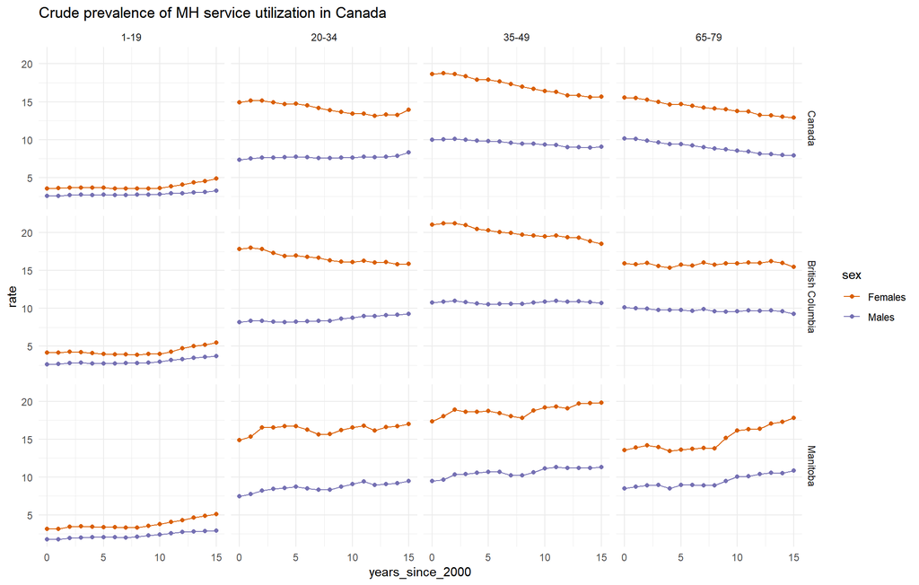

```r
# We need our function to offer us a convenient way to:
# 1. Control the order of the columns (and which are displayed)
# 2. Control the order of the rows    (and which are displayed)
# 3. Control the order and aesthetics of the color dimention

# if we were to pack everything into a single function we would get something like:
make_plot_1_packed <- function(
  d
  ,measure
){
  d1 <- d
  # d1 <- ds1 # for testing and development
  # create support objects
  order_of_age_groups <- d1 %>%
    dplyr::arrange() %>%
    dplyr::distinct(age_group) %>%
    as.list() %>% unlist() %>% as.character()
  # make total value to be at the end of the vector
  order_of_age_groups <- c(setdiff(order_of_age_groups,"1+"),"1+")

  order_of_areas <- d1 %>%
    dplyr::distinct(area) %>%
    dplyr::arrange(area) %>%
    as.list() %>% unlist() %>% as.character()
  # make total value to be at the beginning of the vector
  order_of_areas <- c("Canada", setdiff(order_of_areas, "Canada")  )
  # to customize the order of levels
  levels_sex <- c("Females", "Males","Both sexes")
  #
  d1 <- d %>%
    dplyr::mutate(
      years_since_2000 = year - 2000 # to create a shorter label
      # to enforce the chosen order of the levels:
      ,area            = factor(area,      levels = order_of_areas)
      ,age_group       = factor(age_group, levels = order_of_age_groups)
      ,levels_sex      = factor(sex,       levels = levels_sex)
    )
  # to create custom pallets:

  # descriptive tag              # green     # red      # blue
  palette_sex_dark         <- c("#1b9e77", "#d95f02", "#7570b3") #duller than below
  # palette_sex_dark         <- c("#66c2a5", "#fc8d62", "#8da0cb") #brighter than above
  # taken from http://colorbrewer2.org/#type=qualitative&scheme=Dark2&n=3
  pallete_sex_light        <- adjustcolor(palette_sex_dark, alpha.f = .2)
  names(palette_sex_dark)  <- c("Both sexes", "Females", "Males")
  names(pallete_sex_light) <- names(pallete_sex_light)

  g_out <- d1 %>%
    ggplot(aes_string(
      x      = "years_since_2000"
      ,y     = "rate"
      ,color = "sex"
    ))+
    geom_line( aes_string(group = "sex") )+
    geom_point()+
    facet_grid(area ~ age_group)+
    scale_color_manual(values = palette_sex_dark)+
    # scale_color_manual(values = pallete_sex_light)+
    theme_minimal()+
    labs( title = "Crude prevalence of MH service utilization in Canada")
  return(g_out)
}
# how to use
ds1 %>%
  # to limit the view while in development
  dplyr::filter(age_group %in% c("1-19", "20-34", "35-49", "65-79")) %>%
  dplyr::filter(area %in% c("Canada", "Manitoba", "British Columbia")) %>%
  dplyr::filter(sex %in% c("Males","Females")) %>%
  make_plot_1_packed(measure = "rate")
```

```r
# as you notice, the function got bulkier due to operations needed
# to construct a reference vector for factor levels
# these and other operations are typically best sourced out
# to the `prep_data` function
```

# PHASE 3 - prep data

```r
# let us construct a new `prep_data` function that would
# isolate the preparatory operations from the `make_plot` function
prep_data_plot_1 <- function(
  d_input
  ,set_area      #= c("Canada")
  ,set_age_group #= c("20-34")
  ,set_sex       #= c("Males","Females")
){
  d1 <- d_input  # for within-function use

  d2 <- d1 %>%
    dplyr::filter(area      %in% set_area      ) %>%
    dplyr::filter(age_group %in% set_age_group ) %>%
    dplyr::filter(sex       %in% set_sex       ) %>%
    dplyr::mutate(
      # to create a shorter label
      years_since_2000 = year - 2000
      # to enforce the chosen order of the levels:
      ,area      = factor(area,      levels = set_area)
      ,age_group = factor(age_group, levels = set_age_group)
      ,sex       = factor(sex,       levels = set_sex )
    )
  # to store objects for passing to the `make_plot` function
  l_support <- list()
  l_support[["data"]] <- d2
  l_support[["set"]] <- list() # in case the first element is single
  l_support[["set"]][["sex"]]       <- set_sex
  l_support[["set"]][["area"]]      <- set_area
  l_support[["set"]][["age_group"]] <- set_age_group
  lapply(l_support, class) # view contents
  # the make_plot funtion will rely on the structure and values in l_support

  return(l_support)
}
# how to use
l_support <- ds1 %>%
  prep_data_plot_1(
    set_area      = c("Canada")
    # set_area      = c("Canada", "Manitoba", "British Columbia")
    # ,set_sex       = c("Females", "Males")
    ,set_sex       = c("Both sexes")
    # ,set_age_group = c("1-19",  "35-49", "65-79","1+")
    ,set_age_group = c("1+")
  )
l_support %>% print()
```

```
$data
# A tibble: 16 x 12
   area  condition age_group sex    year  rate rate_cv rate_95_ci_lower rate_95_ci_upper number
   <fct> <chr>     <fct>     <fct> <dbl> <dbl>   <dbl>            <dbl>            <dbl>  <dbl>
 1 Cana~ Use of h~ 1+        Both~  2000 10.7     0.05            10.7             10.7  3.36e6
 2 Cana~ Use of h~ 1+        Both~  2001 10.8     0.05            10.8             10.8  3.43e6
 3 Cana~ Use of h~ 1+        Both~  2002 10.9     0.05            10.8             10.9  3.48e6
 4 Cana~ Use of h~ 1+        Both~  2003 10.8     0.05            10.7             10.8  3.49e6
 5 Cana~ Use of h~ 1+        Both~  2004 10.6     0.05            10.6             10.6  3.48e6
 6 Cana~ Use of h~ 1+        Both~  2005 10.7     0.05            10.6             10.7  3.53e6
 7 Cana~ Use of h~ 1+        Both~  2006 10.5     0.05            10.5             10.6  3.51e6
 8 Cana~ Use of h~ 1+        Both~  2007 10.4     0.05            10.4             10.4  3.49e6
 9 Cana~ Use of h~ 1+        Both~  2008 10.2     0.05            10.2             10.3  3.48e6
10 Cana~ Use of h~ 1+        Both~  2009 10.2     0.05            10.2             10.2  3.49e6
11 Cana~ Use of h~ 1+        Both~  2010 10.0     0.05            10.0             10.0  3.50e6
12 Cana~ Use of h~ 1+        Both~  2011 10.1     0.05            10.1             10.1  3.56e6
13 Cana~ Use of h~ 1+        Both~  2012  9.86    0.05             9.85             9.87 3.53e6
14 Cana~ Use of h~ 1+        Both~  2013  9.9     0.05             9.89             9.91 3.59e6
15 Cana~ Use of h~ 1+        Both~  2014  9.86    0.05             9.85             9.87 3.62e6
16 Cana~ Use of h~ 1+        Both~  2015 10.0     0.05            10.0             10.1  3.61e6
# ... with 2 more variables: population <dbl>, years_since_2000 <dbl>

$set
$set$sex
[1] "Both sexes"

$set$area
[1] "Canada"

$set$age_group
[1] "1+"
```

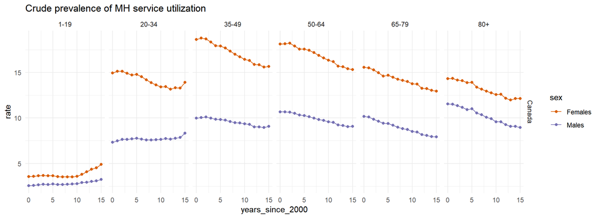

```r
# now we can pass this curated object `l_support` to graphing function
# note that we need to adjust the function to accomodate a new input object
make_plot_1 <- function(
  l_support
  ,measure
){
  d <- l_support$data
  # to customize the color
  # descriptive tag              # green     # red      # blue
  palette_sex_dark         <- c("#1b9e77", "#d95f02", "#7570b3") #duller than below
  # palette_sex_dark         <- c("#66c2a5", "#fc8d62", "#8da0cb") #brighter than above
  # taken from http://colorbrewer2.org/#type=qualitative&scheme=Dark2&n=3
  pallete_sex_light        <- adjustcolor(palette_sex_dark, alpha.f = .2)
  names(palette_sex_dark)  <- c("Both sexes", "Females", "Males")
  names(pallete_sex_light) <- names(pallete_sex_light)

  g_out <- d %>%
    ggplot(aes_string(
      x      = "years_since_2000"
      ,y     = measure
      ,color = "sex"
    ))+
    geom_point()+
    geom_line( aes_string(group = "sex") )+
    facet_grid(area ~ age_group)+
    scale_color_manual(values = palette_sex_dark)+
    # scale_color_manual(values = pallete_sex_light)+
    theme_minimal()+
    labs( title = "Crude prevalence of MH service utilization")
  l_support[["graph"]]   <- g_out
  l_support[["measure"]] <- measure
  return(l_support)
}
# how to use
l_support <- ds1 %>%
  prep_data_plot_1(
    set_area      = c("Canada")
    # set_area      = c("Canada", "Manitoba", "British Columbia")
    ,set_sex       = c("Females", "Males")
    # ,set_sex       = c("Both sexes")
    ,set_age_group = c("1-19", "20-34","35-49","50-64","65-79", "80+")
    # ,set_age_group = c("1+")
  ) %>%
  make_plot_1(measure = "rate")
l_support$graph %>% print()
```

# PHASE 4 - print plot

```r
print_plot_1 <- function(
  l_support
  ,path_output_folder
  ,prefex     = NA
  ,graph_name = "auto"
  ,...
){
  if( graph_name == "auto" ){
    graph_name <- paste0(
      # should be replaced with features appropriate for analysis
      l_support$measure
      ,"-("
      ,l_support$set$sex %>% paste0(collapse = "-")
      ,")-("
      ,l_support$set$area %>% paste0(collapse = "-")
      ,")-("
      ,l_support$set$age_group %>% paste0(collapse = "-")
      ,")"
      ,collapse = "-"
    )
  }else{
    graph_name <- paste0(l_support$measure,"-", graph_name)
  }
  # add a label to distinguish a particular graph (last element in the file name)
  if( !is.na(prefex) ){ # inserts a PREFEX before the graph name
    (path_save_plot <- paste0(path_output_folder, prefex,"-",graph_name) )
  }else{
    ( path_save_plot <- paste0(path_output_folder, graph_name) )
  }

  # if folder does not exist yet, create it
  if( !dir.exists(path_output_folder) ){
    dir.create(path_output_folder)
  }
  # print the graphical object using jpeg device
  path_printed_plot <- paste0(path_save_plot, ".jpg")
  jpeg(
    filename = path_printed_plot
    ,...
  )
  l_support$graph %>% print() # reach into the custom object we made for graphing
  dev.off() # close the device
  l_support[["path_plot"]] <- path_printed_plot
  return(l_support)
}
# how to use
l_support <- ds1 %>%
  prep_data_plot_1(
    set_sex        = c("Females", "Males")
    # set_sex        = c("Females", "Males", "Both sexes")
    ,set_area      = c("Canada", "Manitoba", "British Columbia")
    ,set_age_group = c("1-19",  "35-49", "65-79","1+")
  ) %>%
  make_plot_1(
    measure = "rate"
  ) %>%
  print_plot_1(
    path_output_folder = "./analysis/scenario-3/prints/demo-1/"
    # ,prefex            = "attempt1"
    # ,graph_name        = "take1" # `auto` by default
# options added through `...` into the jpeg() function
    ,width   = 1700
    ,height  = 700
    ,units   = "px"
    ,quality = 100
    ,res     = 200
  )
```

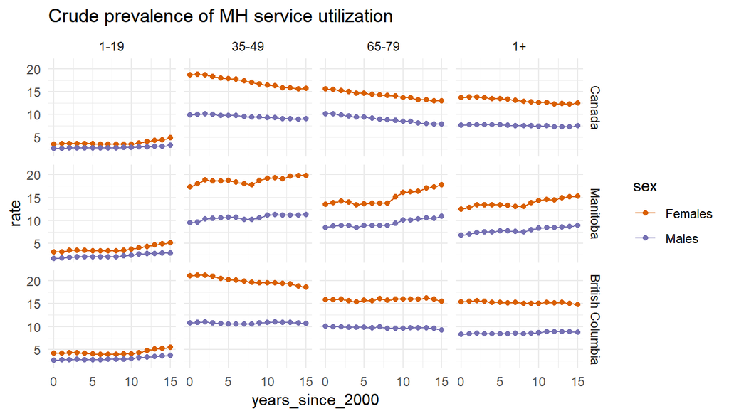

```r
# notice that if I print the GRAPH by reaching into the `l_support` object
# if will be displayed according to the `fig.width`, `fig.height`, and `out.width`
# parameters specified in the chuck options (in the .Rmd file)
l_support$graph %>% print()
```

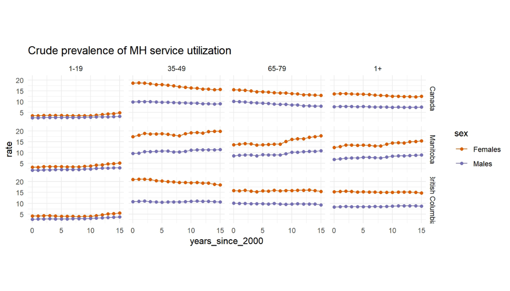

```r
# if, however, we reach into the disk, we will recover the image generated
# with the dimensions and specs defined in the `print_plot` function
l_support$path_plot %>% jpeg::readJPEG() %>% grid::grid.raster()
```

# PHASE 5 - serialize

[figure not shown]

```r
# it often makes sense to genrate a series of plot to be explored manually

# GRAPH SERIES 1
path_target           <- "./analysis/scenario-3/prints/series_1/"
provinces_to_pair     <- c("British Columbia", "Alberta", "Manitoba")
age_groups_to_display <- c("1-19", "20-34", "35-49", "50-64","65-79","80+","1+")
# for each selected province create a comparison with Canada
ls_plot_series <- list()
for(province_i in provinces_to_pair){
  ls_plot_series[[province_i]]  <- ds1 %>%
    prep_data_plot_1(
      set_sex        = c("Females", "Males")
      ,set_area      = c("Canada", province_i)
      ,set_age_group = age_groups_to_display
    ) %>%
    make_plot_1(
      measure = "rate"
    ) %>%
    print_plot_1(
      path_output_folder = path_target
      # options added through `...` into the jpeg() function
      ,width   = 1700
      ,height  = 600
      ,units   = "px"
      ,quality = 100
      ,res     = 200
    )
}
saveRDS(ls_plot_series, paste0(path_target,"ls_plots.rds") )
```

```r
# GRAPH SERIES 2
path_target           <- "./analysis/scenario-3/prints/series_2/"
provinces_to_pair     <- c("British Columbia", "Alberta", "Manitoba")
age_groups_to_display <- c( "+1")
# for each selected province create a comparison with Canada
ls_plot_series <- list()
for(province_i in provinces_to_pair){
  ls_plot_series[[province_i]]  <- ds1 %>%
    prep_data_plot_1(
      set_sex        = c("Males","Females")
      ,set_area      = c("Canada", province_i)
      ,set_age_group = c("20-34", "+1")
    ) %>%
    make_plot_1(
      measure = "rate"
    ) %>%
    print_plot_1(
      path_output_folder = path_target
      # options added through `...` into the jpeg() function
      ,width   = 900
      ,height  = 600
      ,units   = "px"
      ,quality = 100
      ,res     = 200
    )
}
saveRDS(ls_plot_series, paste0(path_target,"ls_plots.rds") )
```

# PHASE 6 - place plot

```r
l_support <- readRDS("./analysis/scenario-3/prints/series_1/ls_plots.rds")
l_support[["British Columbia"]]$path_plot
```

```
[1] "./analysis/scenario-3/prints/series_1/rate-(Females-Males)-(Canada-British Columbia)-(1-19-20-34-35-49-50-64-65-79-80+-1+).jpg"
```

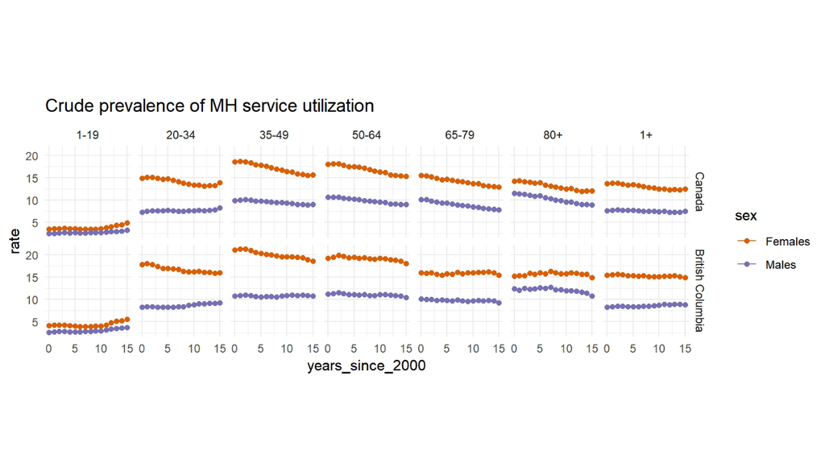

```r
l_support[["British Columbia"]]$path_plot %>% jpeg::readJPEG() %>% grid::grid.raster()
```

# future directions

- how to incorporate additional condition? (i.e. `anxiety_mood` instead of `mental_health`)
- how to add additional INTERNAL dimension? (i.e. `marital_status`)

# session information

For the sake of documentation and reproducibility, the current report was rendered in the following environment. Click the line below to expand.

**Environment**

```
- Session info -----------------------------------------------------------------------------------
 setting  value
 version  R version 3.5.2 (2018-12-20)
 os       Windows >= 8 x64
 system   x86_64, mingw32
 ui       RStudio
 language (EN)
 collate  English_United States.1252
 ctype    English_United States.1252
 tz       America/Los_Angeles
 date     2019-06-19

- Packages ---------------------------------------------------------------------------------------
 package      * version date       lib source
 abind          1.4-5   2016-07-21 [1] CRAN (R 3.5.2)
 assertthat     0.2.1   2019-03-21 [1] CRAN (R 3.5.3)
 backports      1.1.4   2019-04-10 [1] CRAN (R 3.5.3)
 callr          3.2.0   2019-03-15 [1] CRAN (R 3.5.3)
 car            3.0-3   2019-05-27 [1] CRAN (R 3.5.3)
 carData        3.0-2   2018-09-30 [1] CRAN (R 3.5.2)
 cellranger     1.1.0   2016-07-27 [1] CRAN (R 3.5.3)
 cli            1.1.0   2019-03-19 [1] CRAN (R 3.5.3)
 colorspace     1.4-1   2019-03-18 [1] CRAN (R 3.5.3)
 crayon         1.3.4   2017-09-16 [1] CRAN (R 3.5.3)
 curl           3.3     2019-01-10 [1] CRAN (R 3.5.3)
 data.table     1.12.2  2019-04-07 [1] CRAN (R 3.5.3)
 desc           1.2.0   2018-05-01 [1] CRAN (R 3.5.3)
 devtools       2.0.2   2019-04-08 [1] CRAN (R 3.5.3)
 dichromat    * 2.0-0   2013-01-24 [1] CRAN (R 3.5.2)
 digest         0.6.19  2019-05-20 [1] CRAN (R 3.5.3)
 dplyr        * 0.8.1   2019-05-14 [1] CRAN (R 3.5.3)
 DT             0.6     2019-05-09 [1] CRAN (R 3.5.3)
 evaluate       0.14    2019-05-28 [1] CRAN (R 3.5.2)
 explore        0.4.2   2019-05-22 [1] CRAN (R 3.5.3)
 extrafont    * 0.17    2014-12-08 [1] CRAN (R 3.5.2)
 extrafontdb    1.0     2012-06-11 [1] CRAN (R 3.5.2)
 fansi          0.4.0   2018-10-05 [1] CRAN (R 3.5.3)
 forcats        0.4.0   2019-02-17 [1] CRAN (R 3.5.3)
 foreign        0.8-71  2018-07-20 [2] CRAN (R 3.5.2)
 fs             1.3.1   2019-05-06 [1] CRAN (R 3.5.3)
 ggplot2      * 3.1.1   2019-04-07 [1] CRAN (R 3.5.3)
 glue           1.3.1   2019-03-12 [1] CRAN (R 3.5.3)
 gridExtra      2.3     2017-09-09 [1] CRAN (R 3.5.3)
 gtable         0.3.0   2019-03-25 [1] CRAN (R 3.5.3)
 haven          2.1.0   2019-02-19 [1] CRAN (R 3.5.3)
 highr          0.8     2019-03-20 [1] CRAN (R 3.5.3)
 hms            0.4.2   2018-03-10 [1] CRAN (R 3.5.3)
 htmltools      0.3.6   2017-04-28 [1] CRAN (R 3.5.3)
 htmlwidgets    1.3     2018-09-30 [1] CRAN (R 3.5.3)
 httpuv         1.5.1   2019-04-05 [1] CRAN (R 3.5.3)
 httr           1.4.0   2018-12-11 [1] CRAN (R 3.5.3)
 jpeg           0.1-8   2014-01-23 [1] CRAN (R 3.5.2)
 kableExtra     1.1.0   2019-03-16 [1] CRAN (R 3.5.3)
 knitr        * 1.23    2019-05-18 [1] CRAN (R 3.5.2)
 labeling       0.3     2014-08-23 [1] CRAN (R 3.5.2)
 later          0.8.0   2019-02-11 [1] CRAN (R 3.5.3)
 lazyeval       0.2.2   2019-03-15 [1] CRAN (R 3.5.3)
 magrittr     * 1.5     2014-11-22 [1] CRAN (R 3.5.3)
 memoise        1.1.0   2017-04-21 [1] CRAN (R 3.5.3)
 mime           0.6     2018-10-05 [1] CRAN (R 3.5.2)
 munsell        0.5.0   2018-06-12 [1] CRAN (R 3.5.3)
 openxlsx       4.1.0.1 2019-05-28 [1] CRAN (R 3.5.3)
 pillar         1.4.1   2019-05-28 [1] CRAN (R 3.5.2)
 pkgbuild       1.0.3   2019-03-20 [1] CRAN (R 3.5.3)
 pkgconfig      2.0.2   2018-08-16 [1] CRAN (R 3.5.3)
 pkgload        1.0.2   2018-10-29 [1] CRAN (R 3.5.3)
 plyr           1.8.4   2016-06-08 [1] CRAN (R 3.5.3)
 prettyunits    1.0.2   2015-07-13 [1] CRAN (R 3.5.3)
 processx       3.3.1   2019-05-08 [1] CRAN (R 3.5.2)
 promises       1.0.1   2018-04-13 [1] CRAN (R 3.5.3)
 ps             1.3.0   2018-12-21 [1] CRAN (R 3.5.3)
 purrr          0.3.2   2019-03-15 [1] CRAN (R 3.5.3)
 R6             2.4.0   2019-02-14 [1] CRAN (R 3.5.3)
 RColorBrewer * 1.1-2   2014-12-07 [1] CRAN (R 3.5.2)
 Rcpp           1.0.1   2019-03-17 [1] CRAN (R 3.5.3)
 readr          1.3.1   2018-12-21 [1] CRAN (R 3.5.3)
 readxl         1.3.1   2019-03-13 [1] CRAN (R 3.5.3)
 remotes        2.0.4   2019-04-10 [1] CRAN (R 3.5.3)
 reshape2       1.4.3   2017-12-11 [1] CRAN (R 3.5.3)
 rio            0.5.16  2018-11-26 [1] CRAN (R 3.5.3)
 rlang          0.3.4   2019-04-07 [1] CRAN (R 3.5.3)
 rmarkdown      1.13    2019-05-22 [1] CRAN (R 3.5.3)
 rprojroot      1.3-2   2018-01-03 [1] CRAN (R 3.5.3)
 rstudioapi     0.10    2019-03-19 [1] CRAN (R 3.5.3)
 Rttf2pt1       1.3.7   2018-06-29 [1] CRAN (R 3.5.2)
 rvest          0.3.4   2019-05-15 [1] CRAN (R 3.5.3)
 scales         1.0.0   2018-08-09 [1] CRAN (R 3.5.3)
 sessioninfo    1.1.1   2018-11-05 [1] CRAN (R 3.5.3)
 shiny          1.3.2   2019-04-22 [1] CRAN (R 3.5.2)
 stringi        1.4.3   2019-03-12 [1] CRAN (R 3.5.3)
 stringr        1.4.0   2019-02-10 [1] CRAN (R 3.5.3)
 testit         0.9     2018-12-05 [1] CRAN (R 3.5.3)
 tibble         2.1.3   2019-06-06 [1] CRAN (R 3.5.3)
 tidyr          0.8.3   2019-03-01 [1] CRAN (R 3.5.3)
 tidyselect     0.2.5   2018-10-11 [1] CRAN (R 3.5.3)
 usethis        1.5.0   2019-04-07 [1] CRAN (R 3.5.3)
 utf8           1.1.4   2018-05-24 [1] CRAN (R 3.5.3)
 vctrs          0.1.0   2018-11-29 [1] CRAN (R 3.5.3)
 viridis      * 0.5.1   2018-03-29 [1] CRAN (R 3.5.3)
 viridisLite  * 0.3.0   2018-02-01 [1] CRAN (R 3.5.3)
 webshot        0.5.1   2018-09-28 [1] CRAN (R 3.5.3)
 withr          2.1.2   2018-03-15 [1] CRAN (R 3.5.3)
 xfun           0.7     2019-05-14 [1] CRAN (R 3.5.3)
 xml2           1.2.0   2018-01-24 [1] CRAN (R 3.5.3)
 xtable         1.8-4   2019-04-21 [1] CRAN (R 3.5.3)
 yaml           2.2.0   2018-07-25 [1] CRAN (R 3.5.2)
 zeallot        0.1.0   2018-01-28 [1] CRAN (R 3.5.3)
 zip            2.0.2   2019-05-13 [1] CRAN (R 3.5.3)

[1] C:/Users/an499583/Documents/R/win-library/3.5
[2] C:/Program Files/R/R-3.5.2/library
```

Report rendered by an499583 at 2019-06-19, 10:21 -0700 in 22 seconds.